# BiocWorkshops2019

# Copy number variation analysis with Bioconductor

## Workshop information

### Instructor(s) name(s) and contact information

Ludwig Geistlinger, Marcel Ramos, Sehyun Oh, and Levi Waldron

CUNY School of Public Health 55 W 125th St, New York, NY 10027

Ludwig.Geistlinger@sph.cuny.edu Marcel.Ramos@sph.cuny.edu Sehyun.Oh@sph.cuny.edu Levi.Waldron@sph.cuny.edu

### Workshop Description

This workshop gives an overview of Bioconductor solutions for the analysis of copy number variation (CNV) data. The workshop introduces Bioconductor core data structures for efficient representation, access, and manipulation of CNV data, and how to use these containers for structured downstream analysis of CNVs and integration with gene expression and quantitative phenotypes. Participants will be provided with code and hands-on practice for a comprehensive set of typical analysis steps including exploratory analysis, summarizing individual CNV calls across a population, overlap analysis with functional genomic regions and regulatory elements, expression quantitative trait loci (eQTL) analysis, and genome-wide association analysis (GWAS) with quantitative phenotypes. As an advanced application example, the workshop also introduces allele-specific absolute copy number analysis and how it is incorporated in genomic cancer analysis for the estimation of tumor characteristics such as tumor purity and ploidy.

### Pre-requisites

- Basic knowledge of R syntax
- Familiarity with the SummarizedExperiment class
- Familiarity with the GenomicRanges class
- Familiarity with high-throughput genomic assays such as microarrays and next-generation sequencing
- Familiarity with the biological definition of single nucleotide polymorphism (SNP) and copy number variation (CNV)

### Workshop Participation

Execution of example code and hands-on practice

### *R* / *Bioconductor* packages used

- RaggedExperiment
- CNVRanger
- regioneR
- PureCN

### Time outline

| Activity | Time |
| --- | --- |
| Overview | 5m |
| Data representation and manipulation | 20m |
| Integrative downstream analysis (eQTL, GWAS, …) | 20m |
| Allele-specific CN analysis in cancer | 15m |

### Learning Goals

- get familiar with elementary concepts of CNV analysis
- learn how to efficiently represent, access, and manipulate CNV data in Bioconductor data structures
- get familiar with different strategies for summarizing individual CNV calls across a population
- learn how to assess the significance of overlaps between CNVs and functional genomic regions
- learn how carry out association analysis with gene expression and quantitative phenotypes
- get familiar with allele-specific absolute CN analysis of genomic cancer data

### Specific objectives

- understand how CNVs can be experimentally detected and computationally inferred from SNP arrays and next-generation sequencing data
- learn how to use `GRangesList` and `RaggedExperiment` to represent, access, and manipulate CNV data
- understand different strategies for finding recurrent CNV regions in a population, including density trimming, reciprocal overlap, and recurrence significance estimation
- learn how to use the regioneR package to assess the significance of overlaps between CNVs and functional genomic regions such as genes, promoters, and enhancers.
- learn how to carry out eQTL analysis for CNV and RNA-seq data
- learn how to carry out a GWAS analysis for CNV and quantitative phenotype data
- learn how to estimate tumor purity and ploidy from absolute CN analysis with PureCN

## Overview

Copy number variation (CNV) is a frequently observed deviation from the diploid state due to duplication or deletion of genomic regions. CNVs can be experimentally detected based on comparative genomic hybridization, and computationally inferred from SNP-arrays or next-generation sequencing data. These technologies for CNV detection have in common that they report, for each sample under study, genomic regions that are duplicated or deleted with respect to a reference. Such regions are denoted as *CNV calls* in the following and will be considered the starting point for analysis.

## Representation and manipulation of CNV data with RaggedExperiment

`RaggedExperiment` is a flexible data representation for segmented copy number, somatic mutations such as represented in `.vcf` files, and other ragged array schema for genomic location data. Like the `GRangesList` class from `GenomicRanges`, `RaggedExperiment` can be used to represent *differing* genomic ranges on each of a set of samples. In fact, `RaggedExperiment` contains a `GRangesList`:

```r
showClass("RaggedExperiment")
```

```
## Class "RaggedExperiment" [package "RaggedExperiment"]
##
## Slots:
##
## Name:       assays      rowidx      colidx    metadata
## Class: GRangesList     integer     integer        list
##
## Extends: "Annotated"
```

### Constructing a `RaggedExperiment` object

We start with a toy example of two `GRanges` objects, providing ranges on two chromosomes in two samples:

```r
sample1 <- GRanges(
    c(A = "chr1:1-10:-", B = "chr1:8-14:+", C = "chr1:15-18:+"),
    score = 3:5, type=c("germline", "somatic", "germline"))
sample2 <- GRanges(
    c(D = "chr1:1-10:-", E = "chr1:11-18:+"),
    score = 11:12, type=c("germline", "somatic"))
```

Include column data `colData` to describe the samples:

```r
colDat <- DataFrame(id=1:2, status = factor(c("control", "case")))
```

The `RaggedExperiment` can be constructed from individual `Granges`:

```r
(ragexp <- RaggedExperiment(
    sample1 = sample1,
    sample2 = sample2,
    colData = colDat))
```

```
## class: RaggedExperiment
## dim: 5 2
## assays(2): score type
## rownames(5): A B C D E
## colnames(2): sample1 sample2
## colData names(2): id status
```

Or from a `GRangesList`:

```r
grl <- GRangesList(sample1=sample1, sample2=sample2)
ragexp2 <- RaggedExperiment(grl, colData = colDat)
identical(ragexp, ragexp2)
```

```
## [1] TRUE
```

Note that the original ranges are is represented as the `rowRanges` of the `RaggedExperiment`:

```r
rowRanges(ragexp)
```

```
## GRanges object with 5 ranges and 0 metadata columns:
##     seqnames    ranges strand
##        <Rle> <IRanges>  <Rle>
##   A     chr1      1-10      -
##   B     chr1      8-14      +
##   C     chr1     15-18      +
##   D     chr1      1-10      -
##   E     chr1     11-18      +
##   -------
##   seqinfo: 1 sequence from an unspecified genome; no seqlengths
```

### `*Assay` functions

`RaggedExperiment` provides a flexible set of _*Assay_ methods to support transformation of data to matrix format with varying row dimensions.

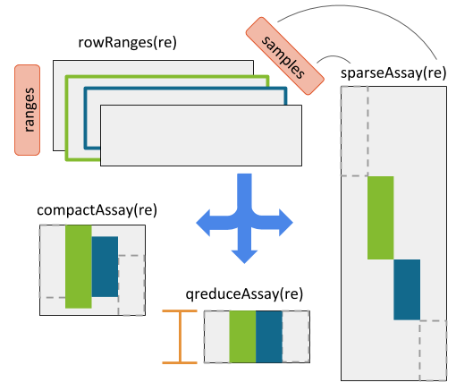

Figure 1: RaggedExperiment object schematic. Rows and columns represent genomic ranges and samples, respectively. Assay operations can be performed with (from left to right) compactAssay, qreduceAssay, and sparseAssay.

The four main *Assay* functions for converting to matrix are:

- sparseAssay: leave ranges exactly as-is
- compactAssay: combine identical ranges
- disjoinAssay: disjoin ranges that overlap across samples
- qreduceAssay: find overlaps with provided “query” ranges

These each have a corresponding function for conversion to RangedSummarizedExperiment.

#### sparseAssay

The most straightforward matrix representation of a `RaggedExperiment` will return a matrix with the number of rows equal to the total number of ranges defined across all samples. *i.e.* the 5 rows of the `sparseAssay` result:

```r
sparseAssay(ragexp)
```

```
##   sample1 sample2
## A       3      NA
## B       4      NA
## C       5      NA
## D      NA      11
## E      NA      12
```

correspond to the ranges of the unlisted `GRangesList`:

```r
unlist(grl)
```

```
## GRanges object with 5 ranges and 2 metadata columns:
##             seqnames    ranges strand |     score        type
##                <Rle> <IRanges>  <Rle> | <integer> <character>
##   sample1.A     chr1      1-10      - |         3    germline
##   sample1.B     chr1      8-14      + |         4     somatic
##   sample1.C     chr1     15-18      + |         5    germline
##   sample2.D     chr1      1-10      - |        11    germline
##   sample2.E     chr1     11-18      + |        12     somatic
##   -------
##   seqinfo: 1 sequence from an unspecified genome; no seqlengths
```

The rownames of the `sparseAssay` result are equal to the names of the `GRanges` elements. The values in the matrix returned by `sparseAssay` correspond to the first columns of the `mcols` of each `GRangesList` element, in this case the “score” column.

Note, this is the default `assay()` method of `RaggedExperiment`:

```r
assay(ragexp, "score")
```

```
##   sample1 sample2
## A       3      NA
## B       4      NA
## C       5      NA
## D      NA      11
## E      NA      12
```

```r
assay(ragexp, "type")
```

```
##   sample1    sample2
## A "germline" NA
## B "somatic"  NA
## C "germline" NA
## D NA         "germline"
## E NA         "somatic"
```

#### compactAssay

The dimensions of the `compactAssay` result differ from that of the `sparseAssay` result only if there are identical ranges in different samples. Identical ranges are placed in the same row in the output. Ranges with any difference in start, end, or strand, will be kept on different rows. Non-disjoint ranges are **not** collapsed.

```r
compactAssay(ragexp)
```

```
##              sample1 sample2
## chr1:8-14:+        4      NA
## chr1:11-18:+      NA      12
## chr1:15-18:+       5      NA
## chr1:1-10:-        3      11
```

```r
compactAssay(ragexp, "type")
```

```
##              sample1    sample2
## chr1:8-14:+  "somatic"  NA
## chr1:11-18:+ NA         "somatic"
## chr1:15-18:+ "germline" NA
## chr1:1-10:-  "germline" "germline"
```

Note that row names are constructed from the ranges, and the names of the `GRanges` vectors are lost, unlike in the `sparseAssay` result.

#### disjoinAssay

This function is similar to `compactAssay` except the rows are *disjoint*[^1] ranges. Elements of the matrix are summarized by applying the `simplifyDisjoin` functional argument to assay values of overlapping ranges.

```r
disjoinAssay(ragexp, simplifyDisjoin = mean)
```

```
##              sample1 sample2
## chr1:8-10:+        4      NA
## chr1:11-14:+       4      12
## chr1:15-18:+       5      12
## chr1:1-10:-        3      11
```

#### qreduceAssay

The `qreduceAssay` function is the most complicated but likely the most useful of the `RaggedExperiment` *Assay* functions. It requires you to provide a `query` argument that is a `GRanges` vector, and the rows of the resulting matrix correspond to the elements of this `GRanges`. The returned matrix will have dimensions `length(query)` by `ncol(x)`. Elements of the resulting matrix correspond to the overlap of the *i* th `query` range in the *j* th sample, summarized according to the `simplifyReduce` functional argument. This can be useful, for example, to calculate per-gene copy number or mutation status by providing the genomic ranges of every gene as the `query`.

The `simplifyReduce` argument in `qreduceAssay` allows the user to summarize overlapping regions with a custom method for the given “query” region of interest. We provide one for calculating a weighted average score per query range, where the weight is proportional to the overlap widths between overlapping ranges and a query range.

*Note* that there are three arguments to this function. See the documentation for additional details.

```r
weightedmean <- function(scores, ranges, qranges)
{
    isects <- pintersect(ranges, qranges)
    sum(scores * width(isects)) / sum(width(isects))
}
```

The call to `qreduceAssay` calculates the overlaps between the ranges of each sample:

```r
grl
```

```
## GRangesList object of length 2:
## $sample1
## GRanges object with 3 ranges and 2 metadata columns:
##     seqnames    ranges strand |     score        type
##        <Rle> <IRanges>  <Rle> | <integer> <character>
##   A     chr1      1-10      - |         3    germline
##   B     chr1      8-14      + |         4     somatic
##   C     chr1     15-18      + |         5    germline
##   -------
##   seqinfo: 1 sequence from an unspecified genome; no seqlengths
##
## $sample2
## GRanges object with 2 ranges and 2 metadata columns:
##     seqnames    ranges strand |     score        type
##        <Rle> <IRanges>  <Rle> | <integer> <character>
##   D     chr1      1-10      - |        11    germline
##   E     chr1     11-18      + |        12     somatic
##   -------
##   seqinfo: 1 sequence from an unspecified genome; no seqlengths
```

with the query ranges (an arbitrary set is defined here for demonstration): First create a demonstration “query” region of interest:

```r
(query <- GRanges(c("chr1:1-14:-", "chr1:15-18:+")))
```

```
## GRanges object with 2 ranges and 0 metadata columns:
##       seqnames    ranges strand
##          <Rle> <IRanges>  <Rle>
##   [1]     chr1      1-14      -
##   [2]     chr1     15-18      +
##   -------
##   seqinfo: 1 sequence from an unspecified genome; no seqlengths
```

using the `simplifyReduce` function to resolve overlapping ranges and return a matrix with rows corresponding to the query:

```r
qreduceAssay(ragexp, query, simplifyReduce = weightedmean)
```

```
##              sample1 sample2
## chr1:1-14:-        3      11
## chr1:15-18:+       5      12
```

### Conversion to RangedSummarizedExperiment

These methods all have corresponding methods to return a `RangedSummarizedExperiment` and preserve the `colData`:

```r
sparseSummarizedExperiment(ragexp)
compactSummarizedExperiment(ragexp)
disjoinSummarizedExperiment(ragexp, simplify = mean)
qreduceSummarizedExperiment(ragexp, query=query, simplify=weightedmean)
```

Please see the `RaggedExperiment` vignette for [more details](http://www.bioconductor.org/packages/release/bioc/vignettes/RaggedExperiment/inst/doc/RaggedExperiment.html).

## Integrative downstream analysis of CNVs with CNVRanger

[figure not shown]

**(A)** The CNVRanger package imports CNV calls from a simple file format into `R`, and stores them in dedicated Bioconductor data structures, and **(B)** implements three frequently used approaches for summarizing CNV calls across a population: *(i)* the CNVRuler that trims region margins based on regional density [Kim et al., 2012](https://doi.org/10.1093/bioinformatics/bts239), *(ii)* the reciprocal overlap procedure that requires sufficient mutual overlap between calls [Conrad et al., 2010](https://doi.org/10.1038/nature08516), and *(iii)* the [GISTIC](http://www.broadinstitute.org/cancer/cga/gistic) procedure that identifies recurrent CNV regions [Beroukhim et al., 2007](https://doi.org/10.1073/pnas.0710052104). **(C)** `CNVRanger` builds on regioneR for overlap analysis of CNVs with functional genomic regions, **(D)** implements RNA-seq expression Quantitative Trait Loci (eQTL) analysis for CNVs by interfacing with edgeR, and **(E)** interfaces with [PLINK](http://zzz.bwh.harvard.edu/plink) for traditional genome-wide association studies (GWAS) between CNVs and quantitative phenotypes.

The key parts of the functionality implemented in `CNVRanger` were developed, described, and applied in several previous studies:

- Genome-wide detection of CNVs and their association with meat tenderness in Nelore cattle [da Silva et al., 2016](https://doi.org/10.1371/journal.pone.0157711)
- Widespread modulation of gene expression by copy number variation in skeletal muscle [Geistlinger et al., 2018](https://doi.org/10.1038/s41598-018-19782-4)
- CNVs are associated with genomic architecture in a songbird [da Silva et al., 2018](https://doi.org/10.1186/s12864-018-4577-1)

### Reading and accessing CNV data

`CNVRanger` uses Bioconductor core data structures implemented in the GenomicRanges and RaggedExperiment packages to represent, access, and manipulate CNV data.

We start by loading the package.

```r
library(CNVRanger)
```

#### Input data format

For demonstration, we consider CNV calls as obtained with [PennCNV](http://penncnv.openbioinformatics.org) from SNP-chip data in a Brazilian cattle breed ([da Silva et al., 2016](https://doi.org/10.1371/journal.pone.0157711)).

Here, we use a data subset and only consider CNV calls on chromosome 1 and 2, for which there are roughly 3000 CNV calls as obtained for 711 samples.

```r
data.dir <- system.file("extdata", package="CNVRanger")
call.file <- file.path(data.dir, "Silva16_PONE_CNV_calls.csv")
calls <- read.csv(call.file, as.is=TRUE)
nrow(calls)
```

```
## [1] 3000
```

```r
head(calls)
```

```
##    chr start    end    NE_id state
## 1 chr1 16947  45013 NE001423     3
## 2 chr1 36337  67130 NE001426     3
## 3 chr1 16947  36337 NE001428     3
## 4 chr1 36337 105963 NE001519     3
## 5 chr1 36337  83412 NE001534     3
## 6 chr1 36337  83412 NE001648     3
```

```r
length(unique(calls[,"NE_id"]))
```

```
## [1] 711
```

#### Representation as a `GRangesList`

We group the calls by sample ID, resulting in a `GRangesList`. Each element of the list corresponds to a sample, and contains the genomic coordinates of the CNV calls for this sample (along with the copy number state in the `State` metadata column).

```r
grl <- makeGRangesListFromDataFrame(calls,
    split.field="NE_id", keep.extra.columns=TRUE)
grl
```

```
## GRangesList object of length 711:
## $NE001357
## GRanges object with 5 ranges and 1 metadata column:
##       seqnames            ranges strand |     state
##          <Rle>         <IRanges>  <Rle> | <integer>
##   [1]     chr1   4569526-4577608      * |         3
##   [2]     chr1 15984544-15996851      * |         1
##   [3]     chr1 38306432-38330161      * |         3
##   [4]     chr1 93730576-93819471      * |         0
##   [5]     chr2 40529044-40540747      * |         3
##   -------
##   seqinfo: 2 sequences from an unspecified genome; no seqlengths
##
## $NE001358
## GRanges object with 1 range and 1 metadata column:
##       seqnames              ranges strand |     state
##          <Rle>           <IRanges>  <Rle> | <integer>
##   [1]     chr1 105042452-105233446      * |         1
##   -------
##   seqinfo: 2 sequences from an unspecified genome; no seqlengths
##
## $NE001359
## GRanges object with 4 ranges and 1 metadata column:
##       seqnames            ranges strand |     state
##          <Rle>         <IRanges>  <Rle> | <integer>
##   [1]     chr1   4569526-4577608      * |         3
##   [2]     chr1 31686841-31695808      * |         0
##   [3]     chr1 93730576-93819471      * |         0
##   [4]     chr2   2527718-2535261      * |         0
##   -------
##   seqinfo: 2 sequences from an unspecified genome; no seqlengths
##
## ...
## <708 more elements>
```

The advantage of representing the CNV calls as a `GRangesList` is that it allows to leverage the comprehensive set of operations on genomic regions implemented in the `GenomicRanges` package - for instance, sorting of the calls according to their genomic coordinates.

```r
grl <- sort(grl)
grl
```

```
## GRangesList object of length 711:
## $NE001357
## GRanges object with 5 ranges and 1 metadata column:
##       seqnames            ranges strand |     state
##          <Rle>         <IRanges>  <Rle> | <integer>
##   [1]     chr1   4569526-4577608      * |         3
##   [2]     chr1 15984544-15996851      * |         1
##   [3]     chr1 38306432-38330161      * |         3
##   [4]     chr1 93730576-93819471      * |         0
##   [5]     chr2 40529044-40540747      * |         3
##   -------
##   seqinfo: 2 sequences from an unspecified genome; no seqlengths
##
## $NE001358
## GRanges object with 1 range and 1 metadata column:
##       seqnames              ranges strand |     state
##          <Rle>           <IRanges>  <Rle> | <integer>
##   [1]     chr1 105042452-105233446      * |         1
##   -------
##   seqinfo: 2 sequences from an unspecified genome; no seqlengths
##
## $NE001359
## GRanges object with 4 ranges and 1 metadata column:
##       seqnames            ranges strand |     state
##          <Rle>         <IRanges>  <Rle> | <integer>
##   [1]     chr1   4569526-4577608      * |         3
##   [2]     chr1 31686841-31695808      * |         0
##   [3]     chr1 93730576-93819471      * |         0
##   [4]     chr2   2527718-2535261      * |         0
##   -------
##   seqinfo: 2 sequences from an unspecified genome; no seqlengths
##
## ...
## <708 more elements>
```

#### Representation as a `RaggedExperiment`

An alternative matrix-like representation of the CNV calls can be obtained with the `RaggedExperiment` data class. It resembles in many aspects the SummarizedExperiment data class for storing gene expression data as e.g. obtained with RNA-seq.

```r
ra <- RaggedExperiment(grl)
ra
```

```
## class: RaggedExperiment
## dim: 3000 711
## assays(1): state
## rownames: NULL
## colnames(711): NE001357 NE001358 ... NE003967 NE003968
## colData names(0):
```

As apparent from the `dim` slot of the object, it stores the CNV calls in the rows and the samples in the columns. Note that the CN state is now represented as an assay matrix which can be easily accessed and subsetted.

```r
assay(ra[1:5,1:5])
```

```
##                        NE001357 NE001358 NE001359 NE001360 NE001361
## chr1:4569526-4577608          3       NA       NA       NA       NA
## chr1:15984544-15996851        1       NA       NA       NA       NA
## chr1:38306432-38330161        3       NA       NA       NA       NA
## chr1:93730576-93819471        0       NA       NA       NA       NA
## chr2:40529044-40540747        3       NA       NA       NA       NA
```

As with `SummarizedExperiment` objects, additional information for the samples are annotated in the `colData` slot. For example, we annotate the steer weight and its feed conversion ratio (FCR) using simulated data. Feed conversion ratio is the ratio of dry matter intake to live-weight gain. A typical range of feed conversion ratios is 4.5-7.5 with a lower number being more desirable as it would indicate that a steer required less feed per pound of gain.

```r
weight <- rnorm(ncol(ra), mean=1100, sd=100)
fcr <- rnorm(ncol(ra), mean=6, sd=1.5)
colData(ra)$weight <- round(weight, digits=2)
colData(ra)$fcr <- round(fcr, digits=2)
colData(ra)
```

```
## DataFrame with 711 rows and 2 columns
##             weight       fcr
##          <numeric> <numeric>
## NE001357   1146.49      5.98
## NE001358   1178.38      7.76
## NE001359   1072.19      5.74
## NE001360   1043.34      7.33
## NE001361   1166.39      5.21
## ...            ...       ...
## NE003962    983.84      5.87
## NE003963     983.1      6.06
## NE003966   1103.54      6.75
## NE003967   1334.75      6.25
## NE003968   1099.83      5.87
```

### Summarizing individual CNV calls across a population

In CNV analysis, it is often of interest to summarize individual calls across the population, (i.e. to define CNV regions), for subsequent association analysis with expression and phenotype data. In the simplest case, this just merges overlapping individual calls into summarized regions. However, this typically inflates CNV region size, and more appropriate approaches have been developed for this purpose.

#### Trimming low-density areas

Here, we use the approach from CNVRuler to summarize CNV calls to CNV regions (see [Figure 1](https://academic.oup.com/view-large/figure/83392426/bts239f1.jpeg) in [Kim et al., 2012](https://doi.org/10.1093/bioinformatics/bts239) for an illustration of the approach). This trims low-density areas as defined by the `density` argument, which is set here to <10% of the number of calls within a summarized region.

```r
cnvrs <- populationRanges(grl, density=0.1)
cnvrs
```

```
## GRanges object with 303 ranges and 2 metadata columns:
##         seqnames              ranges strand |      freq        type
##            <Rle>           <IRanges>  <Rle> | <numeric> <character>
##     [1]     chr1        16947-111645      * |       103        gain
##     [2]     chr1     1419261-1630187      * |        18        gain
##     [3]     chr1     1896112-2004603      * |       218        gain
##     [4]     chr1     4139727-4203274      * |         1        gain
##     [5]     chr1     4554832-4577608      * |        23        gain
##     ...      ...                 ...    ... .       ...         ...
##   [299]     chr2 136310067-136322489      * |         2        loss
##   [300]     chr2 136375337-136386940      * |         1        loss
##   [301]     chr2 136455546-136466040      * |         1        loss
##   [302]     chr2 136749793-136802493      * |        39        both
##   [303]     chr2 139194749-139665914      * |        58        both
##   -------
##   seqinfo: 2 sequences from an unspecified genome; no seqlengths
```

Note that CNV frequency (number of samples overlapping each region) and CNV type (gain, loss, or both) have also been annotated in the columns `freq` and `type`, respectively.

#### Identifying recurrent regions

In particular in cancer, it is important to distinguish driver from passenger mutations, i.e. to distinguish meaningful events from random background aberrations. The [GISTIC](http://www.broadinstitute.org/cancer/cga/gistic) method identifies those regions of the genome that are aberrant more often than would be expected by chance, with greater weight given to high amplitude events (high-level copy-number gains or homozygous deletions) that are less likely to represent random aberrations ([Beroukhim et al., 2007](https://doi.org/10.1073/pnas.0710052104)).

By setting `est.recur=TRUE`, we deploy a `GISTIC`-like significance estimation

```r
cnvrs <- populationRanges(grl, density=0.1, est.recur=TRUE)
cnvrs
```

```
## GRanges object with 303 ranges and 3 metadata columns:
##         seqnames              ranges strand |      freq        type
##            <Rle>           <IRanges>  <Rle> | <numeric> <character>
##     [1]     chr1        16947-111645      * |       103        gain
##     [2]     chr1     1419261-1630187      * |        18        gain
##     [3]     chr1     1896112-2004603      * |       218        gain
##     [4]     chr1     4139727-4203274      * |         1        gain
##     [5]     chr1     4554832-4577608      * |        23        gain
##     ...      ...                 ...    ... .       ...         ...
##   [299]     chr2 136310067-136322489      * |         2        loss
##   [300]     chr2 136375337-136386940      * |         1        loss
##   [301]     chr2 136455546-136466040      * |         1        loss
##   [302]     chr2 136749793-136802493      * |        39        both
##   [303]     chr2 139194749-139665914      * |        58        both
##                      pvalue
##                   <numeric>
##     [1] 0.00980392156862742
##     [2]   0.107843137254902
##     [3]                   0
##     [4]   0.558823529411765
##     [5]  0.0882352941176471
##     ...                 ...
##   [299]   0.236111111111111
##   [300]   0.421296296296296
##   [301]   0.421296296296296
##   [302]  0.0588235294117647
##   [303]  0.0392156862745098
##   -------
##   seqinfo: 2 sequences from an unspecified genome; no seqlengths
```

and filter for recurrent CNVs that exceed a significance threshold of 0.05.

```r
cnvrs[cnvrs$pvalue < 0.05]
```

```
## GRanges object with 17 ranges and 3 metadata columns:
##        seqnames              ranges strand |      freq        type
##           <Rle>           <IRanges>  <Rle> | <numeric> <character>
##    [1]     chr1        16947-111645      * |       103        gain
##    [2]     chr1     1896112-2004603      * |       218        gain
##    [3]     chr1   15984544-15996851      * |       116        loss
##    [4]     chr1   31686841-31695808      * |       274        loss
##    [5]     chr1   69205418-69219486      * |        46        loss
##    ...      ...                 ...    ... .       ...         ...
##   [13]     chr2   97882695-97896935      * |        80        loss
##   [14]     chr2 124330343-124398570      * |        39        loss
##   [15]     chr2 135096060-135271140      * |        84        gain
##   [16]     chr2 135290754-135553033      * |        83        gain
##   [17]     chr2 139194749-139665914      * |        58        both
##                     pvalue
##                  <numeric>
##    [1] 0.00980392156862742
##    [2]                   0
##    [3]  0.0185185185185185
##    [4] 0.00462962962962965
##    [5]  0.0416666666666666
##    ...                 ...
##   [13]  0.0231481481481481
##   [14]  0.0462962962962963
##   [15]  0.0196078431372549
##   [16]  0.0294117647058824
##   [17]  0.0392156862745098
##   -------
##   seqinfo: 2 sequences from an unspecified genome; no seqlengths
```

### Overlap analysis of CNVs with functional genomic regions

Once individual CNV calls have been summarized across the population, it is typically of interest whether the resulting CNV regions overlap with functional genomic regions such as genes, promoters, or enhancers. As a certain amount of overlap can be expected just by chance, an assessment of statistical significance is needed to decide whether the observed overlap is greater (enrichment) or less (depletion) than expected by chance.

The regioneR package implements a general framework for testing overlaps of genomic regions based on permutation sampling. This allows to repeatedly sample random regions from the genome, matching size and chromosomal distribution of the region set under study (here: the CNV regions). By recomputing the overlap with the functional features in each permutation, statistical significance of the observed overlap can be assessed.

We demonstrate in the following how this strategy can be used to assess the overlap between the detected CNV regions and protein-coding regions in the cattle genome. We expect to find a depletion as protein-coding regions are highly conserved and rarely subject to long-range structural variation such as CNV. Hence, is the overlap between CNVs and protein-coding genes less than expected by chance?

To obtain the location of protein-coding genes, we query available *Bos taurus* annotation from Ensembl

```r
library(AnnotationHub)
ah <- AnnotationHub()
```

```
## Using temporary cache /tmp/RtmpSp7b3O/BiocFileCache
```

```
## snapshotDate(): 2019-05-20
```

```
## Using temporary cache /tmp/RtmpSp7b3O/BiocFileCache
```

```r
ahDb <- query(ah, pattern = c("Bos taurus", "EnsDb"))
```

```
## Using temporary cache /tmp/RtmpSp7b3O/BiocFileCache
```

```r
ahDb
```

```
## AnnotationHub with 10 records
## # snapshotDate(): 2019-05-20
## # $dataprovider: Ensembl
## # $species: Bos taurus
## # $rdataclass: EnsDb
## # additional mcols(): taxonomyid, genome, description,
## #   coordinate_1_based, maintainer, rdatadateadded, preparerclass,
## #   tags, rdatapath, sourceurl, sourcetype
## # retrieve records with, e.g., 'object[["AH53189"]]'
##
##             title
##   AH53189 | Ensembl 87 EnsDb for Bos Taurus
##   AH53693 | Ensembl 88 EnsDb for Bos Taurus
##   AH56658 | Ensembl 89 EnsDb for Bos Taurus
##   AH57731 | Ensembl 90 EnsDb for Bos Taurus
##   AH60745 | Ensembl 91 EnsDb for Bos Taurus
##   AH60948 | Ensembl 92 EnsDb for Bos Taurus
##   AH64416 | Ensembl 93 EnsDb for Bos Taurus
##   AH64886 | Ensembl 94 EnsDb for Bos taurus
##   AH67912 | Ensembl 95 EnsDb for Bos taurus
##   AH69141 | Ensembl 96 EnsDb for Bos taurus
```

and retrieve gene coordinates in the UMD3.1 assembly (Ensembl 92).

```r
ahEdb <- ahDb[["AH60948"]]
```

```
## Using temporary cache /tmp/RtmpSp7b3O/BiocFileCache
## Using temporary cache /tmp/RtmpSp7b3O/BiocFileCache
```

```
## downloading 1 resources
```

```
## retrieving 1 resource
```

```
## Using temporary cache /tmp/RtmpSp7b3O/BiocFileCache
```

```
## loading from cache
##     'AH60948 : 67694'
```

```
## require("ensembldb")
```

```
## Using temporary cache /tmp/RtmpSp7b3O/BiocFileCache
## Using temporary cache /tmp/RtmpSp7b3O/BiocFileCache
## Using temporary cache /tmp/RtmpSp7b3O/BiocFileCache
```

```r
bt.genes <- genes(ahEdb)
seqlevels(bt.genes) <- paste0("chr", seqlevels(bt.genes))
bt.genes
```

```
## GRanges object with 24616 ranges and 8 metadata columns:
##                      seqnames              ranges strand |
##                         <Rle>           <IRanges>  <Rle> |
##   ENSBTAG00000046619     chr1         19774-19899      - |
##   ENSBTAG00000006858     chr1         34627-35558      + |
##   ENSBTAG00000039257     chr1         69695-71121      - |
##   ENSBTAG00000035349     chr1         83323-84281      - |
##   ENSBTAG00000001753     chr1       124849-179713      - |
##                  ...      ...                 ...    ... .
##   ENSBTAG00000025951     chrX 148526584-148535857      + |
##   ENSBTAG00000029592     chrX 148538917-148539037      - |
##   ENSBTAG00000016989     chrX 148576705-148582356      - |
##   ENSBTAG00000025952     chrX 148774930-148780901      - |
##   ENSBTAG00000047839     chrX 148804071-148805135      + |
##                                 gene_id   gene_name   gene_biotype
##                             <character> <character>    <character>
##   ENSBTAG00000046619 ENSBTAG00000046619     RF00001           rRNA
##   ENSBTAG00000006858 ENSBTAG00000006858                 pseudogene
##   ENSBTAG00000039257 ENSBTAG00000039257             protein_coding
##   ENSBTAG00000035349 ENSBTAG00000035349                 pseudogene
##   ENSBTAG00000001753 ENSBTAG00000001753             protein_coding
##                  ...                ...         ...            ...
##   ENSBTAG00000025951 ENSBTAG00000025951             protein_coding
##   ENSBTAG00000029592 ENSBTAG00000029592     RF00001           rRNA
##   ENSBTAG00000016989 ENSBTAG00000016989             protein_coding
##   ENSBTAG00000025952 ENSBTAG00000025952             protein_coding
##   ENSBTAG00000047839 ENSBTAG00000047839       P2RY8 protein_coding
##                      seq_coord_system
##                           <character>
##   ENSBTAG00000046619       chromosome
##   ENSBTAG00000006858       chromosome
##   ENSBTAG00000039257       chromosome
##   ENSBTAG00000035349       chromosome
##   ENSBTAG00000001753       chromosome
##                  ...              ...
##   ENSBTAG00000025951       chromosome
##   ENSBTAG00000029592       chromosome
##   ENSBTAG00000016989       chromosome
##   ENSBTAG00000025952       chromosome
##   ENSBTAG00000047839       chromosome
```

[output cut: 13 more lines]

```
##                           gene_id_version      symbol  entrezid
##                               <character> <character>    <list>
##   ENSBTAG00000046619 ENSBTAG00000046619.1     RF00001        NA
##   ENSBTAG00000006858 ENSBTAG00000006858.5                    NA
##   ENSBTAG00000039257 ENSBTAG00000039257.2                    NA
##   ENSBTAG00000035349 ENSBTAG00000035349.3                    NA
##   ENSBTAG00000001753 ENSBTAG00000001753.4                507243
##                  ...                  ...         ...       ...
##   ENSBTAG00000025951 ENSBTAG00000025951.4                    NA
##   ENSBTAG00000029592 ENSBTAG00000029592.1     RF00001        NA
##   ENSBTAG00000016989 ENSBTAG00000016989.5                    NA
##   ENSBTAG00000025952 ENSBTAG00000025952.3                785083
##   ENSBTAG00000047839 ENSBTAG00000047839.1       P2RY8 100299937
##   -------
##   seqinfo: 48 sequences from UMD3.1 genome
```

To speed up the example, we restrict analysis to chromosomes 1 and 2.

```r
sel.genes <- bt.genes[seqnames(bt.genes) %in% c("chr1", "chr2")]
sel.genes <- sel.genes[sel.genes$gene_biotype == "protein_coding"]
sel.cnvrs <- cnvrs[seqnames(cnvrs) %in% c("chr1", "chr2")]
```

Now, we are applying an overlap permutation test with 100 permutations (`ntimes=100`), while maintaining chromosomal distribution of the CNV region set (`per.chromosome=TRUE`). Furthermore, we use the option `count.once=TRUE` to count an overlapping CNV region only once, even if it overlaps with 2 or more genes. We also allow random regions to be sampled from the entire genome (`mask=NA`), although in certain scenarios masking certain regions such as telomeres and centromeres is advisable. Also note that we use 100 permutations for demonstration only. To draw robust conclusions a minimum of 1000 permutations should be carried out.

```r
library(regioneR)
library(BSgenome.Btaurus.UCSC.bosTau6.masked)
res <- suppressWarnings(overlapPermTest(A=sel.cnvrs, B=sel.genes, ntimes=100,
    genome="bosTau6", mask=NA, per.chromosome=TRUE, count.once=TRUE))
res
```

```
## $numOverlaps
## P-value: 0.0495049504950495
## Z-score: -2.2291
## Number of iterations: 100
## Alternative: less
## Evaluation of the original region set: 97
## Evaluation function: numOverlaps
## Randomization function: randomizeRegions
##
## attr(,"class")
## [1] "permTestResultsList"
```

```r
summary(res[[1]]$permuted)
```

```
##    Min. 1st Qu.  Median    Mean 3rd Qu.    Max.
##    91.0   111.0   115.0   115.8   121.0   133.0
```

The resulting permutation *p*-value indicates a significant depletion. Out of the 303 CNV regions, 97 overlap with at least one gene. In contrast, when repeatedly drawing random regions matching the CNV regions in size and chromosomal distribution, the mean number of overlapping regions across permutations was 115.8 $±$ 8.4.

This finding is consistent with our observations across the whole genome ([da Silva et al., 2016](https://doi.org/10.1371/journal.pone.0157711)) and findings from the 1000 Genomes Poject ([Sudmant et al., 2015](https://www.nature.com/articles/nature15394)).

Note: the function `regioneR::permTest` allows to incorporate user-defined functions for randomizing regions and evaluating additional measures of overlap such as total genomic size in bp.

### CNV-expression association analysis

Studies of expression quantitative trait loci (eQTLs) aim at the discovery of genetic variants that explain variation in gene expression levels ([Nica and Dermitzakis, 2013](https://www.ncbi.nlm.nih.gov/pubmed/23650636)). Mainly applied in the context of SNPs, the concept also naturally extends to the analysis of CNVs.

The `CNVRanger` package implements association testing between CNV regions and RNA-seq read counts using `edgeR`, which applies generalized linear models based on the negative-binomial distribution while incorporating normalization factors for different library sizes.

In the case of only one CN state deviating from 2n for a CNV region under investigation, this reduces to the classical 2-group comparison. For more than two states (e.g. 0n, 1n, 2n), edgeR’s ANOVA-like test is applied to test all deviating groups for significant expression differences relative to 2n.

#### Working with individual CNV and RNA-seq assays

We demonstrate the functionality by loading RNA-seq read count data from skeletal muscle samples for 183 Nelore cattle steers, which we analyzed for CNV-expression effects as previously described ([Geistlinger et al., 2018](https://doi.org/10.1038/s41598-018-19782-4)).

```r
rseq.file <- file.path(data.dir, "counts_cleaned.txt")
rcounts <- read.delim(rseq.file, row.names=1, stringsAsFactors=FALSE)
rcounts <- as.matrix(rcounts)
dim(rcounts)
```

```
## [1] 939 183
```

```r
rcounts[1:5, 1:5]
```

```
##                    NE001407 NE001408 NE001424 NE001439 NE001448
## ENSBTAG00000000088       64       65      233      135      134
## ENSBTAG00000000160       20       28       50       13       18
## ENSBTAG00000000176      279      373      679      223      417
## ENSBTAG00000000201      252      271      544      155      334
## ENSBTAG00000000210      268      379      486      172      443
```

For demonstration, we restrict analysis to the 939 genes on chromosome 1 and 2, and store the RNA-seq expression data in a `SummarizedExperiment`.

```r
library(SummarizedExperiment)
rse <- SummarizedExperiment(assays=list(rcounts=rcounts),
                rowRanges=granges(sel.genes)[rownames(rcounts)])
rse
```

```
## class: RangedSummarizedExperiment
## dim: 939 183
## metadata(0):
## assays(1): rcounts
## rownames(939): ENSBTAG00000000088 ENSBTAG00000000160 ...
##   ENSBTAG00000048210 ENSBTAG00000048228
## rowData names(0):
## colnames(183): NE001407 NE001408 ... NE003840 NE003843
## colData names(0):
```

Assuming distinct modes of action, effects observed in the CNV-expression analysis are typically divided into (i) local effects (*cis*), where expression changes coincide with CNVs in the respective genes, and (ii) distal effects (*trans*), where CNVs supposedly affect trans-acting regulators such as transcription factors.

However, due to power considerations and to avoid detection of spurious effects, stringent filtering of (i) not sufficiently expressed genes, and (ii) CNV regions with insufficient sample size in groups deviating from 2n, should be carried out when testing for distal effects. Local effects have a clear spatial indication and the number of genes locating in or close to a CNV region of interest is typically small; testing for differential expression between CN states is thus generally better powered for local effects and less stringent filter criteria can be applied.

In the following, we carry out CNV-expression association analysis by providing the CNV regions to test (`cnvrs`), the individual CNV calls (`grl`) to determine per-sample CN state in each CNV region, the RNA-seq read counts (`rse`), and the size of the genomic window around each CNV region (`window`). The `window` argument thereby determines which genes are considered for testing for each CNV region and is set here to 1 Mbp.

Further, use the `min.cpm` and `min.samples` arguments to exclude from the analysis (i) genes with fewer than `min.cpm` reads per million reads mapped (cpm, counts per million), and (ii) CNV regions with fewer than `min.samples` samples in a group deviating from 2n.

```r
res <- cnvEQTL(cnvrs, grl, rse, window="1Mbp", verbose=TRUE)
```

```
## Restricting analysis to 179 intersecting samples
```

```
## Preprocessing RNA-seq data ...
```

```
## Summarizing per-sample CN state in each CNV region
```

```
## Excluding 286 cnvrs not satisfying min.samples threshold
```

```
## Analyzing 12 regions with >=1 gene in the given window
```

```
## 1 of 12
```

```
## 2 of 12
```

```
## 3 of 12
```

```
## 4 of 12
```

```
## 5 of 12
```

```
## 6 of 12
```

```
## 7 of 12
```

```
## 8 of 12
```

```
## 9 of 12
```

```
## 10 of 12
```

```
## 11 of 12
```

```
## 12 of 12
```

```r
res
```

```
## DataFrame with 89 rows and 5 columns
##                         CNVR               Gene                 logFC
##                  <character>        <character>             <numeric>
## 1          chr1:16947-111645 ENSBTAG00000018278     0.194859708204693
## 2          chr1:16947-111645 ENSBTAG00000021997   -0.0812496004002579
## 3          chr1:16947-111645 ENSBTAG00000020035    0.0745028563584966
## 4          chr1:16947-111645 ENSBTAG00000011528    0.0118392582964246
## 5          chr1:16947-111645 ENSBTAG00000012594  -0.00661188778069866
## ...                      ...                ...                   ...
## 85  chr2:135290754-135553033 ENSBTAG00000030340   -0.0310183382350007
## 86  chr2:135290754-135553033 ENSBTAG00000008314   -0.0148596021181995
## 87  chr2:135290754-135553033 ENSBTAG00000008309    0.0172997593964661
## 88  chr2:135290754-135553033 ENSBTAG00000003403  -0.00336281264078722
## 89  chr2:135290754-135553033 ENSBTAG00000013282 -0.000223673376098313
##                  PValue         AdjPValue
##               <numeric>         <numeric>
## 1   0.00731514635939691 0.400665393143022
## 2     0.179616021014321 0.841564657598637
## 3     0.740325113667423 0.997718543512711
## 4     0.915565410373996 0.997718543512711
## 5     0.943057146391629 0.997718543512711
## ...                 ...               ...
## 85    0.850536851523179 0.997718543512711
## 86    0.869368789923888 0.997718543512711
## 87    0.885514362762372 0.997718543512711
## 88    0.987950415154231 0.997718543512711
## 89    0.997718543512711 0.997718543512711
```

The resulting `DataFrame` contains in the first column the CNV regions tested. The second column contains the genes tested in the genomic window around each CNV region, and the other columns report (i) log2 fold change with respect to the 2n group, (ii) edgeR’s DE *p*-value, and (iii) the (per default) Benjamini-Hochberg adjusted *p*-value.

#### Working with TCGA data stored in a `MultiAssayExperiment`

In the previous section, we individually prepared the CNV and RNA-seq data for CNV-expression association analysis. In the following, we demonstrate how to perform an integrated preparation of the two assays when stored in a MultiAssayExperiment We therefore consider glioblastoma [GBM](https://cancergenome.nih.gov/cancersselected/glioblastomamultiforme) data from The Cancer Genome Atlas [TCGA](https://cancergenome.nih.gov), which can conveniently be accessed with the curatedTCGAData package.

```r
library(curatedTCGAData)
suppressMessages(
    gbm <- curatedTCGAData("GBM",
        assays=c("GISTIC_Peaks", "CNVSNP", "RNASeq2GeneNorm"),
        dry.run=FALSE)
)
gbm
```

```
## A MultiAssayExperiment object of 3 listed
##  experiments with user-defined names and respective classes.
##  Containing an ExperimentList class object of length 3:
##  [1] GBM_CNVSNP-20160128: RaggedExperiment with 146852 rows and 1104 columns
##  [2] GBM_RNASeq2GeneNorm-20160128: SummarizedExperiment with 20501 rows and 166 columns
##  [3] GBM_GISTIC_Peaks-20160128: RangedSummarizedExperiment with 68 rows and 577 columns
## Features:
##  experiments() - obtain the ExperimentList instance
##  colData() - the primary/phenotype DataFrame
##  sampleMap() - the sample availability DataFrame
##  `$`, `[`, `[[` - extract colData columns, subset, or experiment
##  *Format() - convert into a long or wide DataFrame
##  assays() - convert ExperimentList to a SimpleList of matrices
```

The returned `MultiAssayExperiment` contains three assays:

- the SNP-based CNV calls stored in a `RaggedExperiment` (`GBM_CNVSNP`),
- the recurrent CNV regions summarized across the population using the [GISTIC](http://www.broadinstitute.org/cancer/cga/gistic) method (`GBM_GISTIC_Peaks`), and
- the normalized RNA-seq gene expression values in a `SummarizedExperiment` (`GBM_RNASeq2GeneNorm`).

To annotate the genomic coordinates of the genes measured in the RNA-seq assay, we use the function `symbolsToRanges` from the TCGAutils package. For demonstration, we restrict the analysis to chromosome 1 and 2.

```r
library(TCGAutils)
gbm <- suppressMessages(symbolsToRanges(gbm, unmapped=FALSE))
for(i in 1:3)
{
    genome(rowRanges(gbm[[i]])) <- "hg19"
    seqlevelsStyle(rowRanges(gbm[[i]])) <- "UCSC"
    ind <- as.character(seqnames(rowRanges(gbm[[i]]))) %in% c("chr1", "chr2")
    gbm[[i]] <- gbm[[i]][ind,]
}
gbm
```

```
## A MultiAssayExperiment object of 3 listed
##  experiments with user-defined names and respective classes.
##  Containing an ExperimentList class object of length 3:
##  [1] GBM_CNVSNP-20160128: RaggedExperiment with 17818 rows and 1104 columns
##  [2] GBM_GISTIC_Peaks-20160128: RangedSummarizedExperiment with 12 rows and 577 columns
##  [3] GBM_RNASeq2GeneNorm-20160128_ranged: RangedSummarizedExperiment with 2939 rows and 166 columns
## Features:
##  experiments() - obtain the ExperimentList instance
##  colData() - the primary/phenotype DataFrame
##  sampleMap() - the sample availability DataFrame
##  `$`, `[`, `[[` - extract colData columns, subset, or experiment
##  *Format() - convert into a long or wide DataFrame
##  assays() - convert ExperimentList to a SimpleList of matrices
```

We now restrict the analysis to intersecting patients of the three assays using `MultiAssayExperiment`’s `intersectColumns` function, and select *Primary Solid Tumor* samples using the `splitAssays` function from the `TCGAutils` package.

```r
gbm <- intersectColumns(gbm)
sampleTables(gbm)
```

```
## $`GBM_CNVSNP-20160128`
##
##  01  02  10  11
## 154  13 146   1
##
## $`GBM_GISTIC_Peaks-20160128`
##
##  01
## 154
##
## $`GBM_RNASeq2GeneNorm-20160128_ranged`
##
##  01  02
## 147  13
```

```r
data(sampleTypes)
sampleTypes
```

```
##    Code                                        Definition
## 1    01                               Primary Solid Tumor
## 2    02                             Recurrent Solid Tumor
## 3    03   Primary Blood Derived Cancer - Peripheral Blood
## 4    04      Recurrent Blood Derived Cancer - Bone Marrow
## 5    05                          Additional - New Primary
## 6    06                                        Metastatic
## 7    07                             Additional Metastatic
## 8    08                        Human Tumor Original Cells
## 9    09        Primary Blood Derived Cancer - Bone Marrow
## 10   10                              Blood Derived Normal
## 11   11                               Solid Tissue Normal
## 12   12                                Buccal Cell Normal
## 13   13                           EBV Immortalized Normal
## 14   14                                Bone Marrow Normal
```

[output cut: 31 more lines]

```r
gbm <- splitAssays(gbm, sampleCodes="01")
gbm
```

```
## A MultiAssayExperiment object of 3 listed
##  experiments with user-defined names and respective classes.
##  Containing an ExperimentList class object of length 3:
##  [1] 01_GBM_CNVSNP-20160128: RaggedExperiment with 17818 rows and 154 columns
##  [2] 01_GBM_GISTIC_Peaks-20160128: RangedSummarizedExperiment with 12 rows and 154 columns
##  [3] 01_GBM_RNASeq2GeneNorm-20160128_ranged: RangedSummarizedExperiment with 2939 rows and 147 columns
## Features:
##  experiments() - obtain the ExperimentList instance
##  colData() - the primary/phenotype DataFrame
##  sampleMap() - the sample availability DataFrame
##  `$`, `[`, `[[` - extract colData columns, subset, or experiment
##  *Format() - convert into a long or wide DataFrame
##  assays() - convert ExperimentList to a SimpleList of matrices
```

We transform CN estimates into CN states where states are encoded as:

- `0`: homozygous deletion (2-copy loss)
- `1`: heterozygous deletion (1-copy loss)
- `2`: normal diploid state
- `3`: 1-copy gain
- `4`: amplification (>= 2-copy gain)

```r
ind <- grep("CNVSNP", names(gbm))
state <- round(mcols(gbm[[ind]])$Segment_Mean)
state[state > 2] <- 2
state[state < -2] <- -2
mcols(gbm[[ind]])$State <- state + 2
mcols(gbm[[ind]]) <- mcols(gbm[[ind]])[,3:1]
table(mcols(gbm[[ind]])$State)
```

```
##
##     0     1     2     3     4
##  3270  3025 10223   856   444
```

The data is now ready for CNV-expression association analysis, where we find only two CNV regions with sufficient sample size for testing using the default value of 10 for the `minSamples` argument.

```r
res <- cnvEQTL(cnvrs="01_GBM_GISTIC_Peaks-20160128",
    calls="01_GBM_CNVSNP-20160128",
    rcounts="01_GBM_RNASeq2GeneNorm-20160128_ranged",
    data=gbm, window="1Mbp", verbose=TRUE)
```

```
## harmonizing input:
##   removing 154 sampleMap rows not in names(experiments)
```

```
## Preprocessing RNA-seq data ...
```

```
## Summarizing per-sample CN state in each CNV region
```

```
## Excluding 10 cnvrs not satisfying min.samples threshold
```

```
## Analyzing 2 regions with >=1 gene in the given window
```

```
## 1 of 2
```

```
## 2 of 2
```

```r
res
```

```
## DataFrame with 39 rows and 5 columns
##                     CNVR        Gene              logFC
##              <character> <character>          <numeric>
## 1   chr1:3394251-6475685       RPL22 -0.725652140752693
## 2   chr1:3394251-6475685      CAMTA1 -0.710092209593344
## 3   chr1:3394251-6475685      KLHL21 -0.804994378329488
## 4   chr1:3394251-6475685     DNAJC11 -0.639331827106962
## 5   chr1:3394251-6475685       PHF13 -0.644451457052169
## ...                  ...         ...                ...
## 35  chr1:7908902-8336254       VAMP3 -0.380592228642377
## 36  chr1:7908902-8336254        H6PD -0.487860462635182
## 37  chr1:7908902-8336254        PER3 -0.496046999162807
## 38  chr1:7908902-8336254      ERRFI1 -0.503783986501104
## 39  chr1:7908902-8336254      SLC2A5 -0.445492206932205
##                   PValue            AdjPValue
##                <numeric>            <numeric>
## 1   9.61335285501219e-09 1.87460380672738e-07
## 2    2.5708616701305e-07  2.1115304553107e-06
## 3   5.49625845092592e-06 3.57256799310185e-05
## 4   6.45920365913183e-06  3.5986991815163e-05
## 5   1.15203955333233e-05 4.99217139777344e-05
## ...                  ...                  ...
## 35   0.00155925324719568  0.00357711039062539
## 36   0.00420206699725692  0.00819403064465099
## 37    0.0280814360824631   0.0456323336340025
## 38    0.0500141322286501   0.0722717568907876
## 39    0.0643968913279903   0.0866027159238491
```

## Allele-specific CNV analysis with PureCN

For allele-specific copy number alteration (CNA) analysis, most commonly used tools in the field rely on high quality genome-wide data with matched normal profiles, limiting their applicability in clinical settings.

Here, we’re introducing the open-source PureCN R/Bioconductor package in conjunction with widely used variant-calling and copy number segmentation algorithms, for allele-specific CNA analysis from whole exome sequencing (WES) **without matched normals**.

Further information on PureCN and its CNV analysis workflow can be found in the [PureCN vignette](http://www.bioconductor.org/packages/release/bioc/vignettes/PureCN/inst/doc/PureCN.pdf), [PureCN paper](https://doi.org/10.1186/s13029-016-0060-z), and [CNV analysis workflow paper](https://www.biorxiv.org/content/10.1101/552711v1).

### Overview of the workflow

Detailed scripts are available in this [GitHub repo](https://github.com/shbrief/CNVWorkflow_Code).

#### Prepare input files using PureCN and MuTect

PureCN requires three raw inputs and subsequent preprocessing of them before performing purity and ploidy estimation. Here are the list of three raw input files, followed by the simple workflow diagram.

##### 1. BED file

we are analyzing WES data, so we need to know which part of the genome is captured through BED file.

##### 2. **Process-matched** normal BAM files

these allow us to find out what kinds of backgrounds are there, especially technical biases.

##### 3. Tumor BAM files

these contain the genetic changes, both germline and somatic alternations.

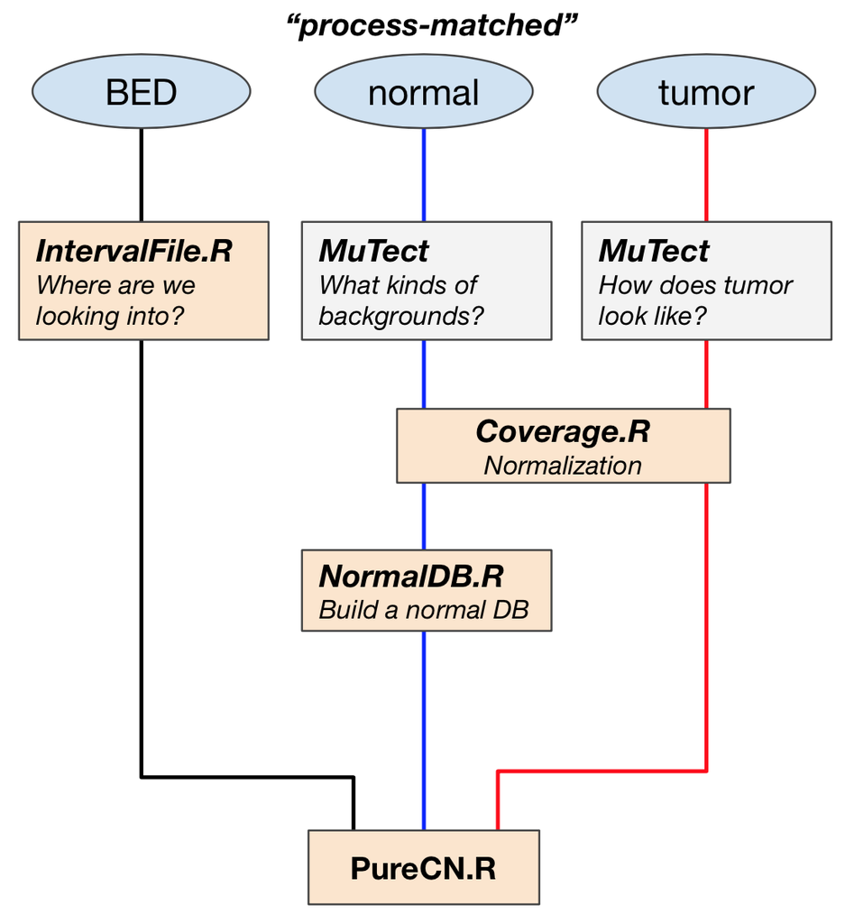

#### Five intermediate files

Preprocessing of three input files creates five major intermediate files that are used directly for purity and ploidy estimation with `PureCN.R` command line tool.

##### 1. Interval file

IntervalFile.R command line tool optimize the targets for copy number calling, for example,

- large targets are split to obtain higher resolution
- targets in regions of low mappability are dropped

One thing you should be careful is to make sure that the genome version of target file matches the reference.

##### 2. VCF and stats files

MuTect is run on `--artifact-detection-mode`,

- which is used when running the caller on a normal (as if it were a tumor) to detect artifacts
- which includes variant calls that are clearly germline
- which is commonly used for Panel-Of-Normals creation

```r
java -jar mutect.jar \
    --analysis_type MuTect \
    -R hg38.fasta \
    --dbsnp $DBSNP_VCF \
    --cosmic $COSMIC_VCF \
    -I:tumor $BAM_TUMOR  \
    -o $OUT/${SAMPLEID}_mutect_stats.txt \
    -vcf $OUT/${SAMPLEID}_mutect.vcf
```

Output VCF files contain both germline SNPs and somatic mutations, which have information about read-depths of reference and alt alleles and whether the variant is in dbSNP. `call_stats.txt` file is an through report of all the metrics and statistics available about the calls made my MuTect and the filtered that are applied internally by default. With this stats file, PureCN will keep germline variants, while removing potential artifacts.

##### 3. Pool of normals (PoN)

Depending on the type of variant you’re looking for, the PON will be generated differently. What all PONs have in common is that,

- they are made from normal samples (in this context, “normal” means derived from healthy tissue that is believed to not have any somatic alterations) and
- their main purpose is to capture recurrent technical artifacts in order to improve the results of the variant calling analysis.

##### 4. GC-normalized coverage files

`Coverage.R` process tumor and normal bam files to calculate GC-normalized coverages. Different library can give different coverage profiles, and the most important library-specific bias is due to GC-content. i.e. regions of high AT- or GC-content are not always captured with exactly the same efficiency in tumor and normals.

##### 5. NormalDB

To build a normalDB for coverage normalization and bias correction, we are providing two intermediate files: 1) the list of coverage normalized files from Coverage.R and 2) normal panel vcf file (PON).

Three outputs from this process are used for PureCN,

- a database of normal samples, which will be used to normalize tumor coverages,
- mapping bias information of each variant. By examining the coverage of particular intervals in a pool of normals, we can estimate how well this assay captures these intervals and will then adjust the tumor coverage accordingly.
- Last is an interval weight file. Interval weights will be set proportional to the inverse of coverage standard deviation across all normals. Intervals with high variance in coverage in the pool of normals are thus down-weighted.

All the pre-processed files above are used as inputs for `PureCN.R` to normalize, segment and determine purity and ploidy. This step returns purity and ploidy combinations, sorted by likelihood score. Provides copy number and LOH data, by both gene and genomic region.

```r
Rscript $PURECN/PureCN.R \
    --out $PCN_OUT/PureCN/tumor_only/$SAMPLEID \
    --tumor $PCN_OUT/tumor_cov/${SAMPLEID}_coverage_loess.txt \
    --SAMPLEID ${SAMPLEID} \
    --vcf $MUTECT_OUT/stat_tumor_only/${SAMPLEID}_mutect.vcf \
    --statsfile $MUTECT_OUT/stat_tumor_only/${SAMPLEID}_mutect_stats.txt \
    --normaldb $PCN_OUT/normalDB/normalDB_hg38.rds \
    --normal_panel $PCN_OUT/normalDB/mapping_bias_hg38.rds \
    --intervals $INPUT/bed/baits_hg38_intervals.txt \
    --intervalweightfile $PCN_OUT/normalDB/interval_weights_hg38.txt \
    --snpblacklist hg38_simpleRepeats.bed \
    --genome hg38 \
    --force --postoptimize --seed 123
```

**Overview of CNV analysis workflow with intermediates**  
Here is the more detailed workflow diagram with the intermediate files described above.

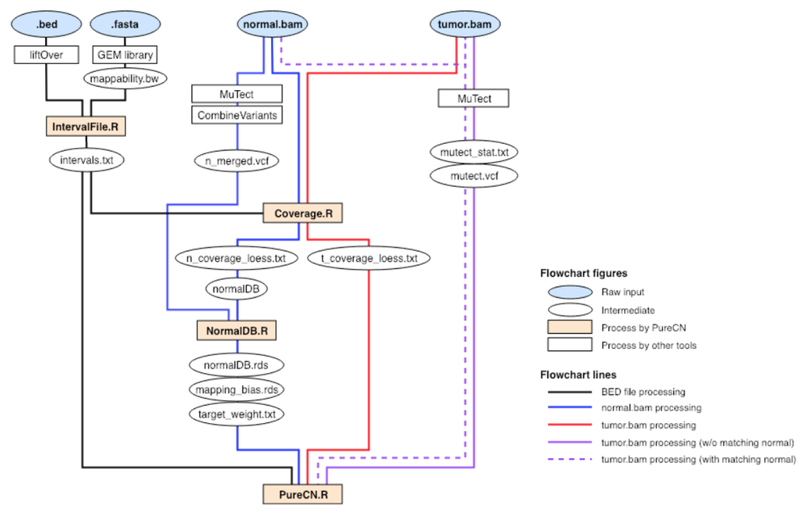

**Requirement for production pipeline**  
As long as you are using the same capture kit and the same sequencing protocols, you need to process only tumor bam files for the production.

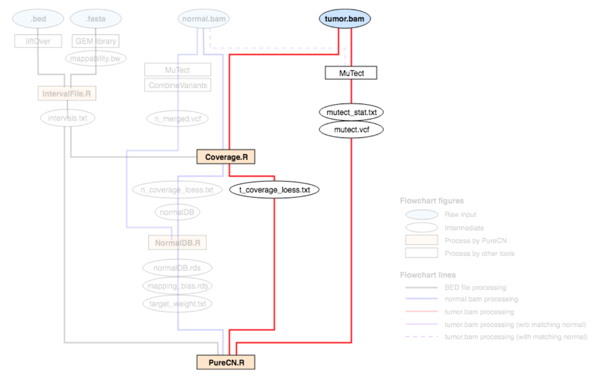

### Analysis examples

##### 1. Overview

The colors visualize the copy number fitting score from low (blue) to high (red). The numbers indicate the ranks of the local optima.

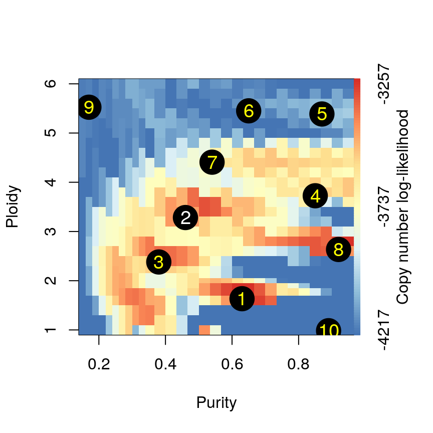

```r
plotAbs(ret, type="overview")
```

##### 2. Log-ratio histogram

This figure displays a histogram of tumor vs. normal copy number log-ratios for the maximum likelihood solution (number 1 of ‘Overview’ plot). The height of a bar in this plot is proportional to the fraction of the genome falling into the particular log-ratio copy number range.

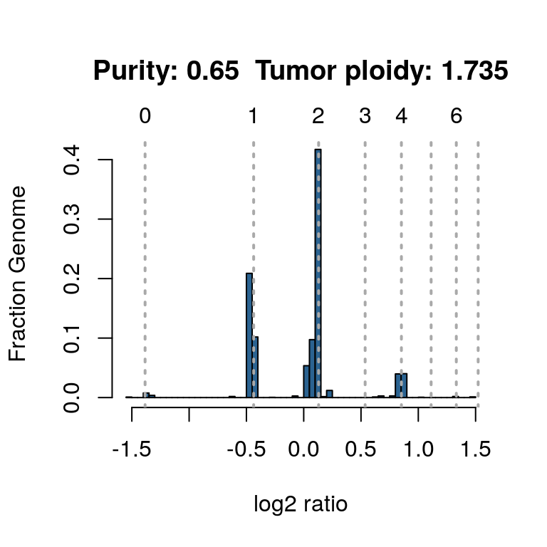

```r
plotAbs(ret, 1, type="hist")
```

```r
createCurationFile(file.rds)
read.csv(system.file("extdata/Sample1_PureCN.csv", package = "CNVWorkshop"))
```

```
##   Sampleid Purity   Ploidy Sex Contamination Flagged Failed Curated
## 1  Sample1   0.65 1.734572   ?             0    TRUE  FALSE   FALSE
##                          Comment
## 1 EXCESSIVE LOSSES;EXCESSIVE LOH
```

##### 3. Amplification and deletion

```r
gene.calls = callAlterations(ret)
head(gene.calls)
```

```
##            chr     start       end C seg.mean seg.id number.targets
## EIF2A     chr3 150270143 150301699 6   1.3351      5             13
## MIR548H2  chr3 151531951 151538241 6   1.3351      5              3
## GPNMB     chr7  23286477  23313844 7   1.4723     17             11
## SH2D4B   chr10  82298088  82403838 0  -1.5118     22              8
## SLC35G1  chr10  95653791  95661248 0  -1.3002     24              3
## CYP2C9   chr10  96698440  96748786 0  -1.3002     24              9
##           gene.mean   gene.min   gene.max focal breakpoints          type
## EIF2A     1.5159387  0.7544062  2.1392167  TRUE           0 AMPLIFICATION
## MIR548H2  0.8261594  0.4682628  1.2000253  TRUE           0 AMPLIFICATION
## GPNMB     1.4490939  0.9397072  1.8200775  TRUE           0 AMPLIFICATION
## SH2D4B   -1.5141982 -1.9281007 -1.2607230 FALSE           0      DELETION
## SLC35G1  -1.5988526 -1.8066816 -1.4493561 FALSE           0      DELETION
## CYP2C9   -1.1901085 -2.1922992 -0.9875222 FALSE           0      DELETION
##          num.snps  M M.flagged  loh
## EIF2A           0 NA        NA   NA
## MIR548H2        0 NA        NA   NA
## GPNMB           0 NA        NA   NA
## SH2D4B          2  0      TRUE TRUE
## SLC35G1         0 NA        NA   NA
## CYP2C9          0 NA        NA   NA
```

##### 4. Genomic regions with LOH

```r
loh = callLOH(ret)
head(loh)
```

```
##    chr     start       end arm C M                       type   seg.mean
## 1 chr1 114515871 121535434   p 2 0 WHOLE ARM COPY-NEUTRAL LOH  0.1209814
## 2 chr1 124535434 248085104   q 2 0 WHOLE ARM COPY-NEUTRAL LOH  0.1209814
## 3 chr2  10262881  92326171   p 1 0              WHOLE ARM LOH -0.4656416
## 4 chr2  95326171 231775678   q 1 0              WHOLE ARM LOH -0.4656416
## 5 chr2 236403331 239039169   q 2 0           COPY-NEUTRAL LOH  0.0193000
## 6 chr3  11888043  90504854   p 2 1                             0.1052000
##   num.mark num.snps M.flagged maf.expected maf.observed
## 1      902       13     FALSE    0.1750000    0.1756325
## 2      902       13     FALSE    0.1750000    0.1756325
## 3      685       13     FALSE    0.2592593    0.2788990
## 4      685       13     FALSE    0.2592593    0.2788990
## 5       88        2      TRUE    0.1750000    0.1736667
## 6      408        1      TRUE    0.5000000    0.4712710
```

#### Example of TCGA-OV and TCGA-LUAD datasets

**1. Purity and Ploidy**  
**2. TMB (Tumor mutation burden)** : TMB is the number of somatic mutations carried by tumor cells.  
**3. Mutational signatures** : Mutational signatures are characteristic combinations of mutation types arising from specific mutagenesis processes, which can provide information on cause and treatment option for different types of cancer.

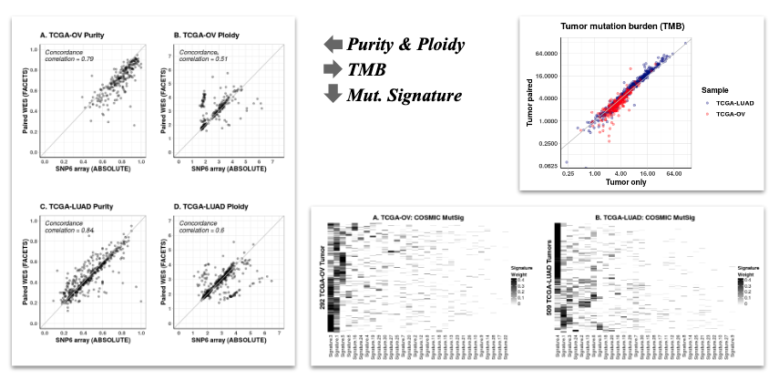

[^1]: A *disjoint* set of ranges has no overlap between any ranges of the set.